# Time Series Regression Model for Consumer Price Index of Alcoholic Beverages and Tobacco

### Lag-1 (Autoregressive) Variable

Now, the CPI of previous month will be added as a feature into the model.

```r
alc_tob_cpi$log_lag_1 <- as.numeric(sapply(1:nrow(alc_tob_cpi), function(x) alc_tob_cpi$log_CPI[x-1]))
#Since the data are shifted by 1, January-2012 lag-1 variable is NA
                                #It is filled with the next lag-1 variable, February 2012
alc_tob_cpi <- alc_tob_cpi %>% fill(log_lag_1, .direction = "up")
```

The model will be constructed by using both trend and lag-1 variables.

```
Call:
lm(formula = log_CPI ~ trend + Dollar_lagged + zam_lagged + log_lag_1,
    data = alc_tob_cpi)

Residuals:
      Min        1Q    Median        3Q       Max
-0.032806 -0.011138 -0.005496  0.000114  0.161104

Coefficients:
               Estimate Std. Error t value Pr(>|t|)
(Intercept)   0.6395521  0.2260316   2.829  0.00558 **
trend         0.0009007  0.0003665   2.457  0.01562 *
Dollar_lagged 0.0018541  0.0044893   0.413  0.68044
zam_lagged    0.0006062  0.0002444   2.480  0.01469 *
log_lag_1     0.8897410  0.0394460  22.556  < 2e-16 ***
---
Signif. codes:  0 '***' 0.001 '**' 0.01 '*' 0.05 '.' 0.1 ' ' 1

Residual standard error: 0.02624 on 106 degrees of freedom
Multiple R-squared:  0.9927,	Adjusted R-squared:  0.9924
F-statistic:  3612 on 4 and 106 DF,  p-value: < 2.2e-16
```

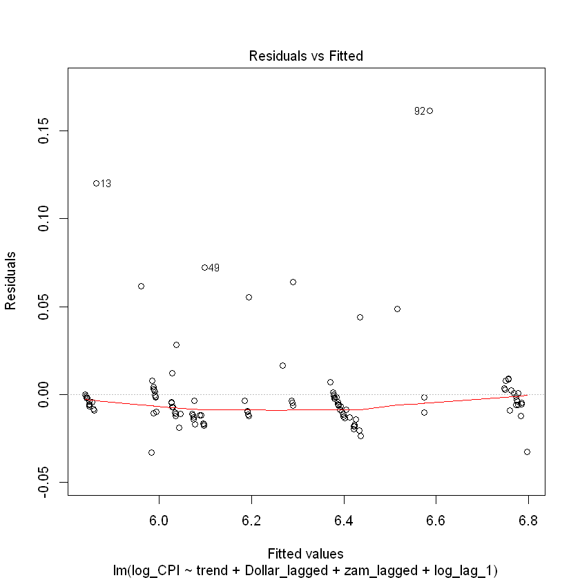

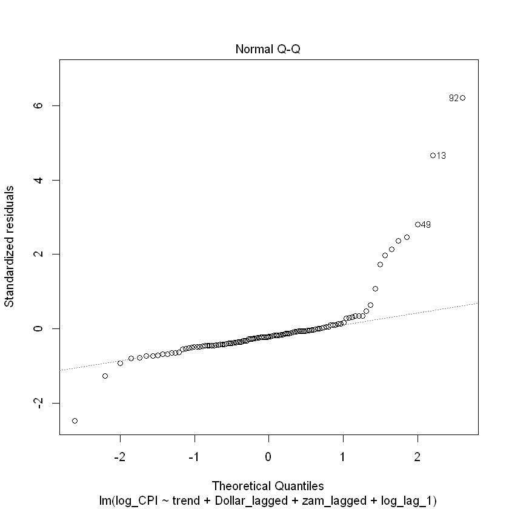

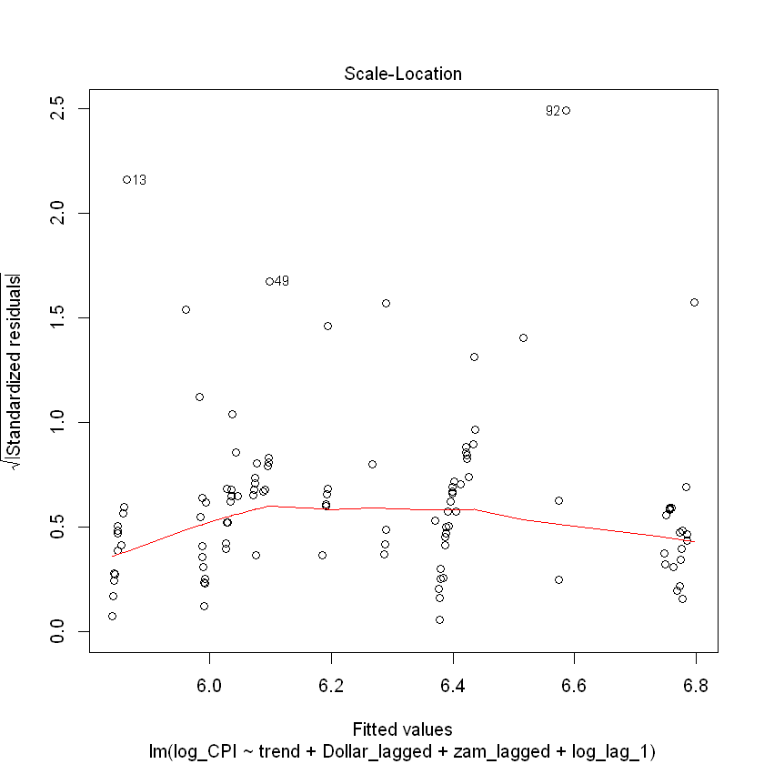

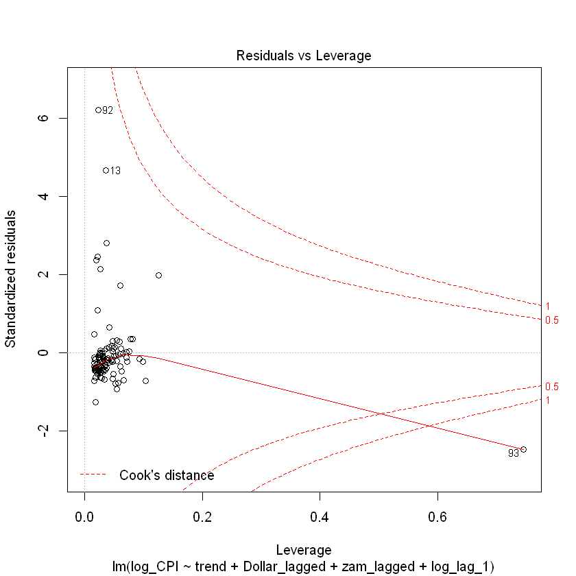

```r
model_6 = lm(log_CPI~trend+Dollar_lagged+zam_lagged+log_lag_1, data = alc_tob_cpi)
summary(model_6)
plot(model_6)
```

It can be easily realized that the model performance is increased. Trend, the search volume, and lag-1 CPI variables are statistically significant. The interesting observation is that the USD-TRY exchange rate is no longer statistically significant. The reason is that autoregressive variables dominate the other variable in theory. It can be proven from the coefficients of the independent variables. The exchange rate may be removed from the model, but the model will not be probably improved much. Adjusted R-squared value is almost 1, which is suspicious. When the residuals are compared to fitted values, it can be seen that residuals seem to have linear relationship with fitted values and they are generally negative, which means the predictions are usually higher then the actual observations. The randomness in residuals is incresaed compared to the models above.

The reason of such an increment in the performance is that prices of cigarettes and alcohols are "sticky" in short run. When their prices are increased, they have the same price in a long period, approximately one year. Using lag-1 variable gives an intuition that the price will be probably the same on the next month.

To verify the model, we need to see the autocorrelation graphs.

```
	Breusch-Godfrey test for serial correlation of order up to 10

data:  Residuals
LM test = 6.9254, df = 10, p-value = 0.7325
```

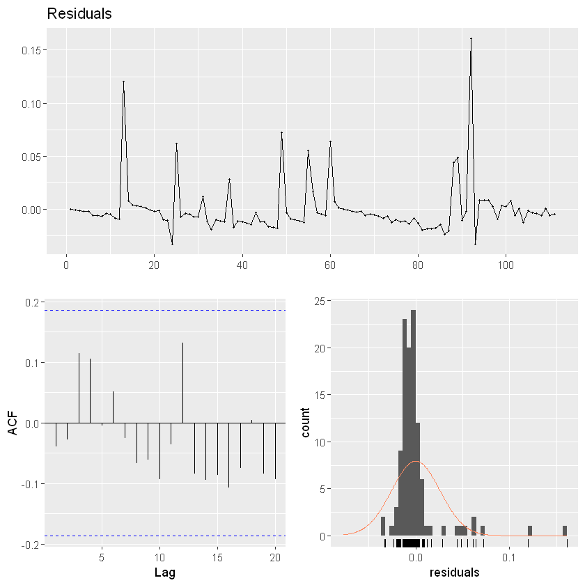

```r
checkresiduals(model_6)
```

According to Breusch-Godfrey test, we fail to reject null hypothesis, which is that there is no autocorrelation in residuals. There are some peaks in residuals, which occur on the month which the prices of the products get a rise. The model cannot easily detect the sudden increases, as expected. In addition, residuals almost have a normal distribution, but there are some outliers which result in some distortions in the distribution. They may be removed at the final model. Autocorrelation in residuals seems to be eliminated now.

The correlation between variables will be explored here.

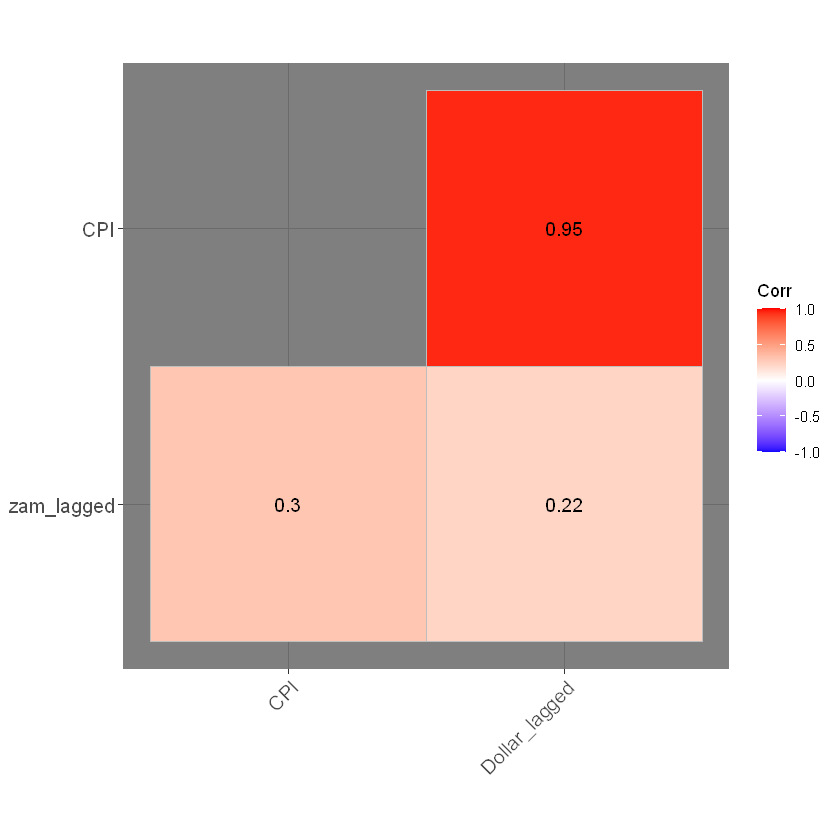

```r
corr <- cor(alc_tob_cpi[,list(CPI,Dollar_lagged,zam_lagged)])
ggcorrplot(corr,
  hc.order = TRUE, type = "lower",
  lab = TRUE,
  ggtheme = ggplot2::theme_dark(),
)
```

It is interesting that the highest correlation exists between CPI and the exchange rate although the rate is not significant in the final model. The reason is that they both have an upward trend. Especially, in the last 2 years, they both increased much. However, the search volume is helpful only when a sudden increase in prices happens. Therefore, the correlation between CPI and the search volume is low.

Now, the predictions will be made plotted to compare to the actual observations.

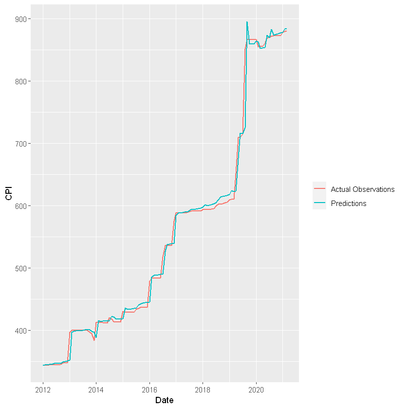

```r
alc_tob_cpi[,predictions:=exp(predict(model_6,alc_tob_cpi))]
ggplot(alc_tob_cpi ,aes(x=Date)) +
        geom_line(aes(y=CPI,color='Actual Observations'), size = 0.7) +
        geom_line(aes(y=predictions,color='Predictions'), size = 0.7) +
        theme(legend.title = element_blank())
```

It can be seen that predictions are very close to the actual observations. The leading reason for this situation is to have autoregressive variable in the model because CPI has not shown a random distribution since 2012. As mentioned above, the prices are sticky in the short run. The price on next month will be probably very close to the current price. Another reason is given above, which is that autoregressive variables may reduce the other variables' effects on the dependent variable.

Now, we will predict the consumer price index of alcohols and tobaccos. Then, we will compare the actual CPI in April.

```r
april_2021_pred <- data.frame(
  trend = alc_tob_cpi[.N,trend+1],
    Dollar_lagged=alc_tob_cpi[.N,Dollar],
    zam_lagged = alc_tob_cpi[.N,zam],
    log_lag_1 = alc_tob_cpi[.N,log_CPI]
)


paste0("The predicted consumer price index of alcohols and tobacco in April is ",round(exp(predict(model_6,april_2021_pred)),2)," TL, according to the model.")
data_path = "C:/Users/Alkim/Desktop/8. Dönem/IE 360/Homework 2/CPI_with_April..xlsx"
April=read.xlsx(data_path,sheet='EVDS')
April <- tail(April,1)
colnames(April) <- c("Date", "CPI")
paste0("The real consumer price index of alcohols and tobacco in April ",April$CPI," TL.")
paste0("The difference is ", round(exp(predict(model_6,april_2021_pred)),2) - April$CPI , " TL")
```

'The predicted consumer price index of alcohols and tobacco in April is 886.98 TL, according to the model.'

'The real consumer price index of alcohols and tobacco in April 886.09 TL.'

'The difference is 0.889999999999986 TL'

The model is very successful according to the result above. Our model predicted the CPI in April only 0.89 TL more than the actual value.

# Conclusion

- Consumer price index (CPI) of alcohols and tobaccos have an upward trend in the long run. Therefore, the variables having a similar trend seem to be statistically significant.
- CPI does not change in a some period, generally 1 year, in other words, prices are "sticky" in the short run.
- Since the prices are highly affected by the taxes, and sticky in the short run, they jump to the new level after this period and stay there.
- There is no monthly or yearly seasonal behavior.
- The exchange rate has a high correlation with CPI, but it is not a significant independent variable in the model.
- The search volume of "sigaraya zam" is very informative about the sudden jumps in CPI.
- The price of previous month is the most significant dependent variable in the model. The reasons are that the prices are generally steady, and autoregressive variables dominates the other independent variables. The price at the next month will be probably very close to the price at current month.
- Consumer confidence index does not affect CPI significantly.